# 8. Named Entity Recognition

# 3. Targeted Sentiment Analysis

- Leverage appropriate NLP techniques to identify organizations, people, and locations, then apply targeted sentiment.
  1. What types of companies (based on the lines of business) are planning to invest in these technologies today or near future (success stories)?
  - Create appropriate visualization to summarize your recommendations (i.e. word cloud chart or bubble chart)
  2. What types of applications cannot currently be transformed by AI, based on today's state of technology (failures)?
  - Create appropriate visualization to summarize your recommendations (i.e. word cloud chart or bubble chart)

```python
news.sample(3, random_state = 42)
```

|  | url | date | language | title | text | year | month | day | text_ner | text_cleaned | ... | vader_comp | text_tokens | bert_topics | bert_words | entities | ner_person | ner_norp | ner_org | ner_gpe | ner_loc |
| --- | --- | --- | --- | --- | --- | --- | --- | --- | --- | --- | --- | --- | --- | --- | --- | --- | --- | --- | --- | --- | --- |
| 60898 | https://www.finanzen.at/nachrichten/aktien/cog... | 2023-08-04 | en | Cognizant expands generative AI partnership wi... | \n\nCognizant expands generative AI partnershi... | 2023 | 8 | 8 | Cognizant expands generative AI partnership wi... | cognizant expands generative ai partnership go... | ... | 0.9974 | [cognizant, expands, generative, ai, partnersh... | 170 | [aktien, sie, zu, im, aktie, atx, dax, der, un... | [[AI, ORG], [Google Cloud, ORG], [02.08.23 fin... | [Nasdaq 0,4, TrackerIndex TrackerInline, Track... | [] | [AI, Google Cloud, ListeDow Jones ListeNikkei2... | [N.J., U.S., Gewinn] | [Google Cloud, Google Cloud] |
| 40342 | https://www.mccourier.com/medical-inflation-de... | 2021-02-25 | en | Medical Inflation Devices Market Size, Share, ... | \nMedical Inflation Devices Market Size, Share... | 2021 | 2 | 2 | Medical Inflation Devices Market Size, Share, ... | medical inflation devices market size share op... | ... | 0.9995 | [medical, inflation, device, market, size, sha... | 5 | [market, analysis, player, growth, forecast, g... | [[Medical Inflation Devices Market Size, ORG],... | [Bosch Sohn Vehicle, Occupant Sensing, Robert ... | [Reddit] | [Medical Inflation Devices Market Size, Foreca... | [US, US, Razer, C.R., Tiffany, Laofengxiang, T... | [North America, Middle East Africa, Asia Pacif... |
| 72825 | https://telecoms.com/521516/us-and-uk-regulato... | 2023-05-04 | en | US and UK regulators talk up the need for AI r... | \nUS and UK regulators talk up the need for AI... | 2023 | 5 | 5 | US and UK regulators talk up the need for AI r... | us uk regulators talk need ai regulation news ... | ... | 0.9979 | [u, uk, regulator, talk, need, ai, regulation,... | 12 | [regulation, cookie, government, law, federal,... | [[US, GPE], [UK, GPE], [AI, ORG], [Telecoms.co... | [Andrew Wooden, Lina Khan, Rubicon, Meta Faceb... | [Facebook, Filipino] | [AI, Telecoms.com News Analysis Back Infograph... | [US, UK, US, UK, US, Big Tech, A.I., UK, UK, A... | [] |

3 rows × 27 columns

# Healthcare

```python
# Assuming 'news' is your DataFrame and it has a 'month' column
news['year_month'] = news['year'].astype(str) + '-' + news['month'].astype(str).str.zfill(2)
positive_news = news[(news['vader_sent'] == 'positive') & (news['bert_topics'] == 3)][['year_month', 'vader_sent']]
```

```python
# Count the number of positive sentiment articles per year-month
positive_counts = positive_news['year_month'].value_counts().sort_index()
```

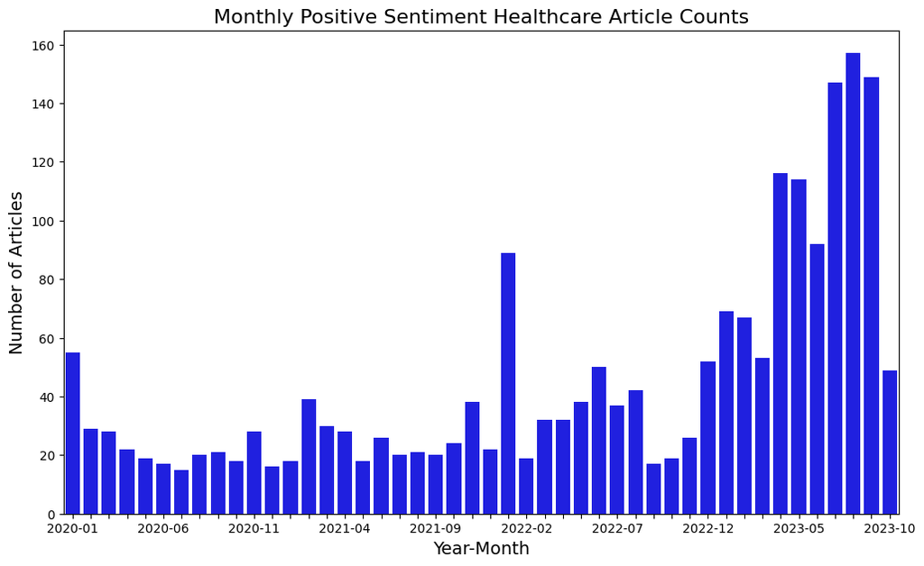

```python
# Create a bar chart
plt.figure(figsize=(12, 7))
sns.barplot(x=positive_counts.index, y=positive_counts.values, color='blue')

# Enhance the plot
plt.title('Monthly Positive Sentiment Healthcare Article Counts', fontsize=16)
plt.xlabel('Year-Month', fontsize=14)
plt.ylabel('Number of Articles', fontsize=14)
# plt.xticks(rotation=45)
# Skip some xlabels
every_nth = 5  # Change this number to display every nth label
for n, label in enumerate(plt.gca().xaxis.get_ticklabels()):
    if n % every_nth != 0:
        label.set_visible(False)

# Show the plot
plt.show()
```

```python
# Assuming 'news' is your original DataFrame
# Filter the DataFrame for rows where 'bert_topic' is 3
filtered_news = news[news['bert_topics'] == 3]

# Flatten the list of organizations in 'ner_org' into a single list
all_orgs = [org for sublist in filtered_news['ner_org'] for org in sublist]

# Count the occurrences of each organization
org_counts = Counter(all_orgs)

# Convert the counts to a DataFrame
org_count_df = pd.DataFrame(org_counts.items(), columns=['Organization', 'Count'])
```

```python
org_count_df = org_count_df.sort_values(by = 'Count', ascending = False).reset_index(drop = True)
```

# Hardware

```python
# Assuming 'news' is your DataFrame and it has a 'month' column
news['year_month'] = news['year'].astype(str) + '-' + news['month'].astype(str).str.zfill(2)
positive_news = news[(news['vader_sent'] == 'positive') & (news['bert_topics'] == 13)][['year_month', 'vader_sent']]
```

```python
# Count the number of positive sentiment articles per year-month
positive_counts = positive_news['year_month'].value_counts().sort_index()
```

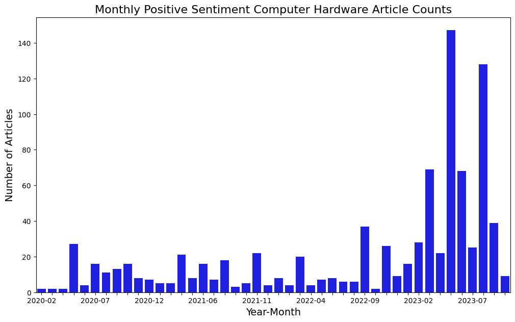

```python
# Create a bar chart
plt.figure(figsize=(12, 7))
sns.barplot(x=positive_counts.index, y=positive_counts.values, color='blue')

# Enhance the plot
plt.title('Monthly Positive Sentiment Computer Hardware Article Counts', fontsize=16)
plt.xlabel('Year-Month', fontsize=14)
plt.ylabel('Number of Articles', fontsize=14)
# plt.xticks(rotation=45)
# Skip some xlabels
every_nth = 5  # Change this number to display every nth label
for n, label in enumerate(plt.gca().xaxis.get_ticklabels()):
    if n % every_nth != 0:
        label.set_visible(False)

# Show the plot
plt.show()
```

### Generative AI

```python
# Assuming 'news' is your DataFrame and it has a 'month' column
news['year_month'] = news['year'].astype(str) + '-' + news['month'].astype(str).str.zfill(2)
positive_news = news[(news['vader_sent'] == 'positive') & (news['bert_topics'] == 4)][['year_month', 'vader_sent']]
```

```python
# Count the number of positive sentiment articles per year-month
positive_counts = positive_news['year_month'].value_counts().sort_index()
```

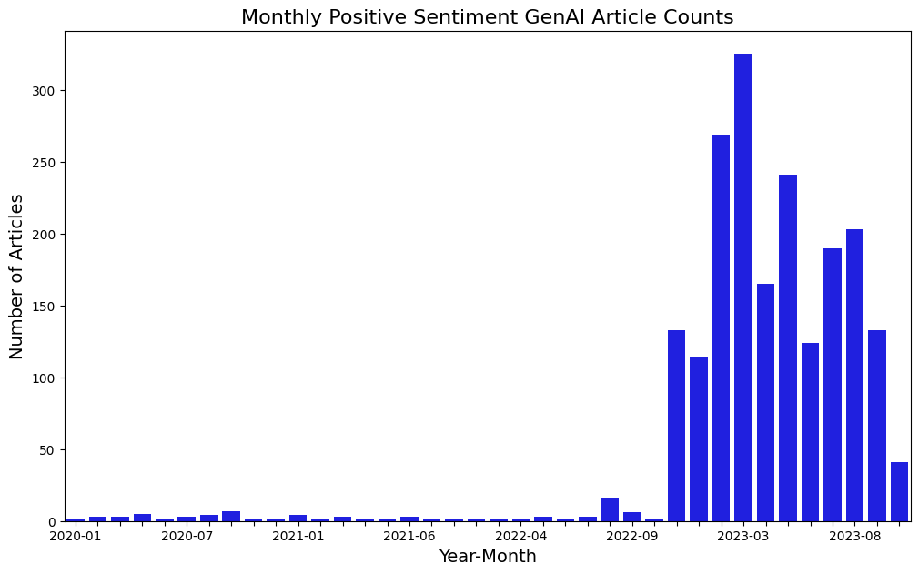

```python
# Create a bar chart
plt.figure(figsize=(12, 7))
sns.barplot(x=positive_counts.index, y=positive_counts.values, color='blue')

# Enhance the plot
plt.title('Monthly Positive Sentiment GenAI Article Counts', fontsize=16)
plt.xlabel('Year-Month', fontsize=14)
plt.ylabel('Number of Articles', fontsize=14)
# plt.xticks(rotation=45)
# Skip some xlabels
every_nth = 5  # Change this number to display every nth label
for n, label in enumerate(plt.gca().xaxis.get_ticklabels()):
    if n % every_nth != 0:
        label.set_visible(False)

# Show the plot
plt.show()
```

# Music

```python
# Assuming 'news' is your DataFrame and it has a 'month' column
news['year_month'] = news['year'].astype(str) + '-' + news['month'].astype(str).str.zfill(2)
positive_news = news[(news['vader_sent'] == 'positive') & (news['bert_topics'] == 17)][['year_month', 'vader_sent']]
```

```python
# Count the number of positive sentiment articles per year-month
positive_counts = positive_news['year_month'].value_counts().sort_index()
```

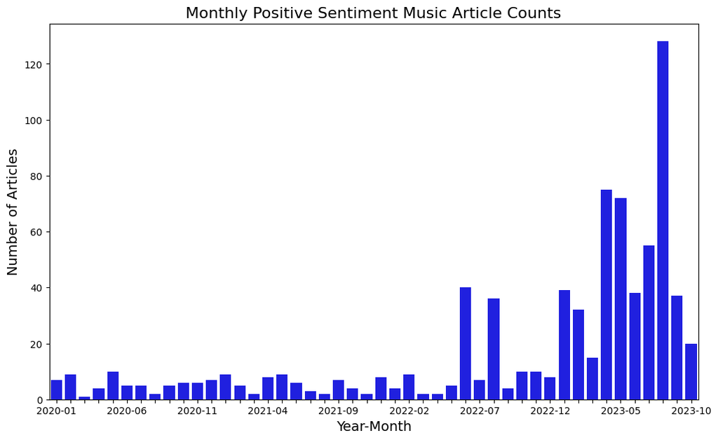

```python
# Create a bar chart
plt.figure(figsize=(12, 7))
sns.barplot(x=positive_counts.index, y=positive_counts.values, color='blue')

# Enhance the plot
plt.title('Monthly Positive Sentiment Music Article Counts', fontsize=16)
plt.xlabel('Year-Month', fontsize=14)
plt.ylabel('Number of Articles', fontsize=14)
# plt.xticks(rotation=45)
# Skip some xlabels
every_nth = 5  # Change this number to display every nth label
for n, label in enumerate(plt.gca().xaxis.get_ticklabels()):
    if n % every_nth != 0:
        label.set_visible(False)

# Show the plot
plt.show()
```

# Market Intelligence

```python
# Assuming 'news' is your DataFrame and it has a 'month' column
news['year_month'] = news['year'].astype(str) + '-' + news['month'].astype(str).str.zfill(2)
positive_news = news[(news['vader_sent'] == 'positive') & (news['bert_topics'] == 5)][['year_month', 'vader_sent']]
```

```python
# Count the number of positive sentiment articles per year-month
positive_counts = positive_news['year_month'].value_counts().sort_index()
```

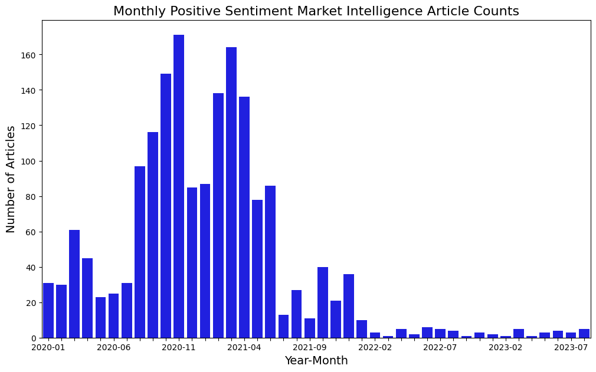

```python
# Create a bar chart
plt.figure(figsize=(12, 7))
sns.barplot(x=positive_counts.index, y=positive_counts.values, color='blue')

# Enhance the plot
plt.title('Monthly Positive Sentiment Market Intelligence Article Counts', fontsize=16)
plt.xlabel('Year-Month', fontsize=14)
plt.ylabel('Number of Articles', fontsize=14)
# plt.xticks(rotation=45)
# Skip some xlabels
every_nth = 5  # Change this number to display every nth label
for n, label in enumerate(plt.gca().xaxis.get_ticklabels()):
    if n % every_nth != 0:
        label.set_visible(False)

# Show the plot
plt.show()
```

```python
%%time

file_path = 'bert_po_topic_info.parquet'
topic_info = pd.read_parquet(file_path)
```

```
CPU times: user 70 ms, sys: 28.9 ms, total: 99 ms
Wall time: 121 ms
```

```python
topic_info.head(20)
```

|  | Topic | Count | Name | Representation | Representative_Docs | Num_Tokens |
| --- | --- | --- | --- | --- | --- | --- |
| 0 | -1 | 73177 | -1_to_ai_of_and | [to, ai, of, and, the, that, is, for, with, in] | [Robot named Curly uses AI to beat one of the ... | 16821 |
| 1 | 0 | 2600 | 0_market_analysis_players_growth | [market, analysis, players, growth, global, fo... | [Healthcare Artificial Intelligence Market is ... | 4611 |
| 2 | 1 | 2383 | 1_ment_cision_entertain_overviewview | [ment, cision, entertain, overviewview, consum... | [Statement from Ray Kurzweil, Inventor, Best S... | 4419 |
| 3 | 2 | 2305 | 2_newswires_presswire_ein_us | [newswires, presswire, ein, us, guinea, releas... | [Global Artificial Intelligence AI Market Anal... | 3685 |
| 4 | 3 | 1334 | 3_entrepreneur_data_automation_venturebeat | [entrepreneur, data, automation, venturebeat, ... | [How Small Businesses Can Leverage AI to Battl... | 14858 |
| 5 | 4 | 1271 | 4_market_artificial_intelligence_analysis | [market, artificial, intelligence, analysis, g... | [Artificial Intelligence Service Market to Wit... | 3823 |
| 6 | 5 | 1139 | 5_nvidia_amd_gpus_gpu | [nvidia, amd, gpus, gpu, chips, intel, chip, a... | [Nvidia CEO highlights chips for the historic ... | 5697 |
| 7 | 6 | 1043 | 6_und_zu_die_hoc | [und, zu, die, hoc, sie, von, auf, taufrufe7, ... | [Global Artificial Intelligence AI Chips Marke... | 2684 |
| 8 | 7 | 987 | 7_hunt_rank_product_connectstoriestech | [hunt, rank, product, connectstoriestech, hunt... | [Why Answer your kids questions with ChatGPT P... | 621 |
| 9 | 8 | 965 | 8_wfmz_berks_lehigh_tv | [wfmz, berks, lehigh, tv, traffic, valley, all... | [MARCHé Leverages AI Solutions to Grow Amazon ... | 4687 |
| 10 | 9 | 842 | 9_wlrn_npr_schedule_donate | [wlrn, npr, schedule, donate, radio, programs,... | [The Microsoft Google AI war WLRN Search Query... | 6217 |
| 11 | 10 | 769 | 10_philanthropic_foundation_mavins_philanthropy | [philanthropic, foundation, mavins, philanthro... | [A philanthropic drive to aid Black women is g... | 5899 |
| 12 | 11 | 761 | 11_venturebeat_follow_vb_homepage | [venturebeat, follow, vb, homepage, gamesbeat,... | [Report of tech leaders say that AI will drive... | 2209 |
| 13 | 12 | 753 | 12_music_song_songs_artists | [music, song, songs, artists, album, musicians... | [How patten used text to audio AI to make an e... | 13487 |
| 14 | 13 | 693 | 13_hinton_humans_human_humanity | [hinton, humans, human, humanity, he, could, b... | [Artificial Intelligence Scientists warn of AI... | 10590 |
| 15 | 14 | 643 | 14_catheters_catheter_vascular_market | [catheters, catheter, vascular, market, urinar... | [Urinary Catheters Market to Witness Huge Grow... | 3688 |
| 16 | 15 | 643 | 15_scripps_delays_closings_watch | [scripps, delays, closings, watch, weather, mo... | [Snapchat launches new AI chatbot weather aler... | 2447 |
| 17 | 16 | 619 | 16_india_vs_viral_latestly | [india, vs, viral, latestly, festivals, mumbai... | [AI Chatbot Salesforce Owned Enterprise Chat A... | 6437 |
| 18 | 17 | 609 | 17_covid_coronavirus_virus_disease | [covid, coronavirus, virus, disease, pandemic,... | [Machine Learning Models to Help Identify Long... | 6602 |
| 19 | 18 | 609 | 18_writers_hollywood_actors_film | [writers, hollywood, actors, film, strike, stu... | [What Hollywood actors, writers strikes have t... | 4423 |

```python
%%time

file_path = 'bert_ne_topic_info.parquet'
topic_info_ne = pd.read_parquet(file_path)
```

```
CPU times: user 33.7 ms, sys: 16.9 ms, total: 50.6 ms
Wall time: 60.2 ms
```

```python
topic_info_ne.head(20)
```

|  | Topic | Count | Name | Representation | Representative_Docs |
| --- | --- | --- | --- | --- | --- |
| 0 | -1 | 2234 | -1_the_and_to_of | [the, and, to, of, in, ai, is, that, for, on] | [EXPLAINER What is ChatGPT and why are schools... |
| 1 | 0 | 175 | 0_jones_florida_rebekah_she | [jones, florida, rebekah, she, warrant, state,... | [Ex Florida data scientist Rebekah Jones plans... |
| 2 | 1 | 142 | 1_students_chatgpt_exam_cheating | [students, chatgpt, exam, cheating, university... | [EXPLAINER What is ChatGPT and why are schools... |
| 3 | 2 | 114 | 2_italy_openai_data_chatgpt | [italy, openai, data, chatgpt, italian, protec... | [Italy temporarily blocks ChatGPT over privacy... |
| 4 | 3 | 110 | 3_humanity_ai_extinction_could | [humanity, ai, extinction, could, risks, human... | [Artificial Intelligence Raises Risk of Extinc... |
| 5 | 4 | 100 | 4_bard_google_being_chatbot | [bard, google, being, chatbot, or, chatgpt, ma... | [Google has long dominated search, and it s ab... |
| 6 | 5 | 95 | 5_fraud_financial_complyadvantage_resistant | [fraud, financial, complyadvantage, resistant,... | [Resistant AI and ComplyAdvantage Launch AI Tr... |
| 7 | 6 | 92 | 6_india_delhi_opindia_modi | [india, delhi, opindia, modi, indian, vs, febr... | [Nvidia CEO Jensen Huang meets PM Modi, highli... |
| 8 | 7 | 90 | 7_fox_county_ai_news | [fox, county, ai, news, public, atlanta, that,... | [Misinformation machines AI chatbots can spew ... |
| 9 | 8 | 90 | 8_breast_cancer_radiologists_screening | [breast, cancer, radiologists, screening, mamm... | [Artificial Intelligence Is Helping Improve Br... |
| 10 | 9 | 90 | 9_images_trump_higgins_midjourney | [images, trump, higgins, midjourney, image, pu... | [Trump arrested Putin jailed Fake AI images sp... |
| 11 | 10 | 87 | 10_gebru_google_mitchell_timnit | [gebru, google, mitchell, timnit, researcher, ... | [Google fires AI researcher, one of few Black ... |
| 12 | 11 | 81 | 11_suicide_safetylit_suicidal_aa | [suicide, safetylit, suicidal, aa, machine, le... | [SafetyLit A comparative study of machine lear... |
| 13 | 12 | 80 | 12_clearview_facial_recognition_privacy | [clearview, facial, recognition, privacy, enfo... | [If you re worried about the end of privacy, d... |
| 14 | 13 | 78 | 13_india_flight_air_express | [india, flight, air, express, kozhikode, passe... | [Kozhikode plane crash injured passengers disc... |
| 15 | 14 | 78 | 14_number_markets_datanetchng_dataprice | [number, markets, datanetchng, dataprice, cana... | [Nvidia s Surge Sharpens Focus on Hunt for AI ... |
| 16 | 15 | 74 | 15_safetylit_aa_update_severity | [safetylit, aa, update, severity, doi, pdf, ma... | [SafetyLit The chance of a traffic collision i... |
| 17 | 16 | 71 | 16_images_child_abuse_sexual | [images, child, abuse, sexual, porn, deepfake,... | [Deepfake porn could be a growing problem amid... |
| 18 | 17 | 70 | 17_chevron_cnn_oregon_idaho | [chevron, cnn, oregon, idaho, ktvz, bend, loca... | [Chinese police detain man for allegedly using... |
| 19 | 18 | 68 | 18_china_chinese_chips_chip | [china, chinese, chips, chip, beijing, taiwan,... | [Pull US AI Research Out of China NewsBreakSea... |